# homework2

James(Changhwan) Han (3923257)

4/8/2022

```r
abalone <- read.csv("abalone.csv")
head(abalone)
```

```
##   type longest_shell diameter height whole_weight shucked_weight viscera_weight
## 1    M         0.455    0.365  0.095       0.5140         0.2245         0.1010
## 2    M         0.350    0.265  0.090       0.2255         0.0995         0.0485
## 3    F         0.530    0.420  0.135       0.6770         0.2565         0.1415
## 4    M         0.440    0.365  0.125       0.5160         0.2155         0.1140
## 5    I         0.330    0.255  0.080       0.2050         0.0895         0.0395
## 6    I         0.425    0.300  0.095       0.3515         0.1410         0.0775
##   shell_weight rings
## 1        0.150    15
## 2        0.070     7
## 3        0.210     9
## 4        0.155    10
## 5        0.055     7
## 6        0.120     8
```

# Question 1

Add age to the data set and describe the distribution of age

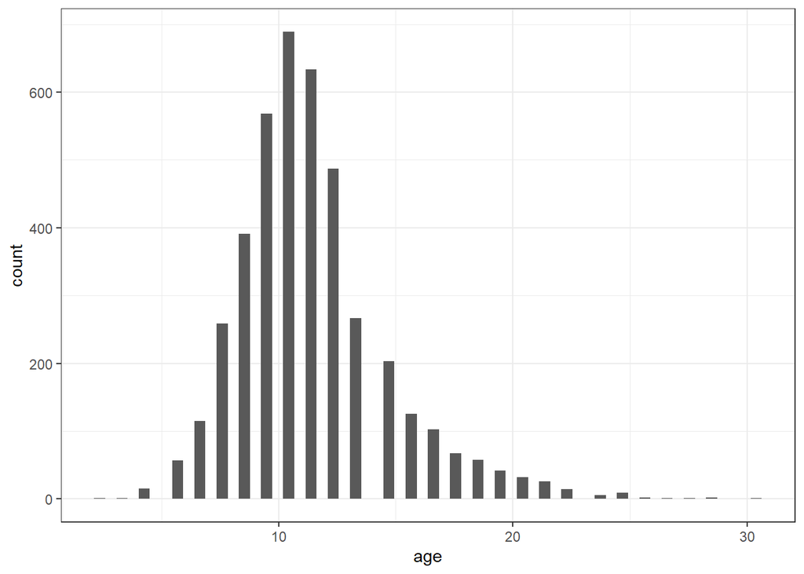

```r
abalone <- abalone %>%
  mutate(age = rings + 1.5)

abalone %>%
  ggplot(aes(x = age)) +
  geom_histogram(bins = 60) +
  theme_bw()
```

# Question 2

Split the abalone data into a training/testing set using stratified sampling.

```r
set.seed(1014)

abalone2 <- subset(abalone, select = -rings)

abalone_split <- initial_split(abalone2, prop = 0.80,
                               strata = age)
abalone_train <- training(abalone_split)
abalone_test <- training(abalone_split)
```

# Question 3

Create a recipe predicting age with all other predictor variables. Shouldn’t include rings

```r
# 1. dummy code categorical predictors
abalone_recipe <- recipe(age ~ ., data = abalone_train) %>%
  step_dummy(all_nominal_predictors())

abalone_recipe
```

```
## Recipe
##
## Inputs:
##
##       role #variables
##    outcome          1
##  predictor          8
##
## Operations:
##
## Dummy variables from all_nominal_predictors()
```

```r
# 2. creating interactions between type/shucked_weight, longest_shell/diameter, and shucked_weight/shell_weight.
# 3.4. center/scale all predictors
abalone_mod <- abalone_recipe %>%
  step_interact(terms = ~ starts_with("type"):shucked_weight + longest_shell:diameter + shucked_weight:shell_weight) %>%
  step_center(all_predictors()) %>%
  step_scale(all_predictors())


abalone_mod
```

```
## Recipe
##
## Inputs:
##
##       role #variables
##    outcome          1
##  predictor          8
##
## Operations:
##
## Dummy variables from all_nominal_predictors()
## Interactions with starts_with("type"):shucked_weight + longest_shell...
## Centering for all_predictors()
## Scaling for all_predictors()
```

# Question 4

Create and store a linear regression object using “lm”

```r
lm_model <- linear_reg() %>%
  set_engine("lm")

lm_model
```

```
## Linear Regression Model Specification (regression)
##
## Computational engine: lm
```

# Question 5

1. set up empty work flow
2. add the model from Q4
3. add the recipe from Q3

```r
lm_wflow <- workflow() %>%
  add_model(lm_model) %>%
  add_recipe(abalone_mod)

lm_wflow
```

```
## == Workflow ====================================================================
## Preprocessor: Recipe
## Model: linear_reg()
##
## -- Preprocessor ----------------------------------------------------------------
## 4 Recipe Steps
##
## * step_dummy()
## * step_interact()
## * step_center()
## * step_scale()
##
## -- Model -----------------------------------------------------------------------
## Linear Regression Model Specification (regression)
##
## Computational engine: lm
```

# Question 6

Use fit() object to predict the age of a hypothetical female abalone

```r
lm_fit <- fit(lm_wflow, abalone_train)
female_age <- data.frame(longest_shell = 0.50, diameter = 0.10, height = 0.30, whole_weight = 4, shucked_weight = 1, viscera_weight = 2, shell_weight = 1, type='F')

predict(lm_fit, female_age)
```

```
## # A tibble: 1 x 1
##   .pred
##   <dbl>
## 1  24.1
```

# Question 7

1. Create a metric set includes R2, RMSE, and MAE
2. Use predict() and bind_cols() to create a tibble of model’s predicted values from the training data along with the actual observed ages
3. apply metric set to the tibble, report the results, and interpret the R^2

```r
abalone_train_res <- predict(lm_fit, new_data = abalone_train %>% select(-age))
abalone_train_res <- bind_cols(abalone_train_res, abalone_train %>% select(age))
rmse(abalone_train_res, truth = age, estimate = .pred)
```

```
## # A tibble: 1 x 3
##   .metric .estimator .estimate
##   <chr>   <chr>          <dbl>
## 1 rmse    standard        2.11
```

```r
abalone_metrics <- metric_set(rmse, rsq, mae)
abalone_metrics(abalone_train_res, truth = age,
                estimate = .pred)
```

```
## # A tibble: 3 x 3
##   .metric .estimator .estimate
##   <chr>   <chr>          <dbl>
## 1 rmse    standard       2.11
## 2 rsq     standard       0.567
## 3 mae     standard       1.51
```

The result for R^2 is 0.567. Above 50% of data fit in the data.

# Question 8

$Var(\hat{f(x_0)})$ and $[Bias(\hat{f(x_0)})]^2$ are the reproducible error, and $Var(\epsilon)$ is the irreducible error.

# Question 9

Assuming $Var(\hat{f(x_0)}) + [Bias(\hat{f(x_0)})]^2$ is zero, the irreducible error is the minimum value of expected test MSE.

# Question 10

$$\begin{aligned}
&E\left[\left(y_{0}-\hat{f}\left(x_{0}\right)\right)^{2}\right]=\operatorname{Var}\left(\hat{f}\left(x_{0}\right)\right)+\left[\operatorname{Bias}\left(\hat{f}\left(x_{0}\right)\right)\right]^{2}+\operatorname{Var}(\epsilon) \\
&=E\left[\left(\hat{f}\left(x_{0}\right)-E\left[\hat{f}\left(x_{0}\right)\right]\right)^{2}\right]+\left[E\left[\hat{f}\left(x_{0}\right)\right]-f\left(x_{0}\right)\right]^{2}+\operatorname{Var}(\epsilon) \\
&\bullet E\left[\left(\hat{f}\left(x_{0}\right)-E\left[\hat{f}\left(x_{0}\right)\right]\right)^{2}\right]=0 \bullet\left[E\left[\hat{f}\left(x_{0}\right)\right]-f\left(x_{0}\right)\right]^{2}=0 \\
&E\left[\left(y_{0}-\hat{f}\left(x_{0}\right)\right)^{2}\right]=0+0+\operatorname{Var}(\epsilon)=\operatorname{Var}(\epsilon)
\end{aligned}$$